# Practical Machine Learning Course Project

J. Schlueter

07/20/2020

# Practical Machine Learning Course Project - Prediction Assignment Writeup

## Overview

This is the course project for the Practical Machine Learning Course on Coursera offered by Johns Hopkins University. The goal of this assignment is to predict the manner in which 6 participants performed barbell lifts (correctly and incorrectly in 5 different ways). We will build three different prediction models (including cross validation) and determine their out-of-sample-errors. In our case, the prediction model with the smallest error is random forest. This model will be used to predict 20 different test cases.

## Background

Using devices such as Jawbone Up, Nike FuelBand, and Fitbit it is now possible to collect a large amount of data about personal activity relatively inexpensively. These type of devices are part of the quantified self movement – a group of enthusiasts who take measurements about themselves regularly to improve their health, to find patterns in their behavior, or because they are tech geeks. One thing that people regularly do is quantify how much of a particular activity they do, but they rarely quantify how well they do it. In this project, the goal will be to use data from accelerometers on the belt, forearm, arm, and dumbell of 6 participants. They were asked to perform barbell lifts correctly and incorrectly in 5 different ways. More information is available from the website here: http://groupware.les.inf.puc-rio.br/har (see the section on the Weight Lifting Exercise Dataset).

## Data and Exploratory Analysis

### Data set

The training data for this project are available here:

https://d396qusza40orc.cloudfront.net/predmachlearn/pml-training.csv

The test data are available here:

https://d396qusza40orc.cloudfront.net/predmachlearn/pml-testing.csv

The data for this project come from this source: http://groupware.les.inf.puc-rio.br/har.

### Loading the Data

We start by loading the R packages and files required for our analysis. Furthermore, we set the seed to make this analysis reproducible.

```r
library(knitr)
library(data.table)
library(caret)
library(corrplot)
library(rpart)
library(rattle)
library(randomForest)
library(xgboost)
set.seed(123)

# Checking if data folder already exists.
if(!file.exists("data")){
    dir.create("data")
}

# Download datasets, checking if they already exist in wd
filename1 <- "data/train_set.csv"
filename2 <- "data/test_set.csv"

fileUrl1 <- "http://d396qusza40orc.cloudfront.net/predmachlearn/pml-training.csv"
fileUrl2 <- "http://d396qusza40orc.cloudfront.net/predmachlearn/pml-testing.csv"

if(!file.exists(filename1)){
        download.file(fileUrl1, destfile = filename1)}
if(!file.exists(filename2)){
        download.file(fileUrl2, destfile = filename2)}

list.files("./data")
```

```
## [1] "test_set.csv"  "train_set.csv"
```

```r
#Load datasets
train <- read.csv(filename1)
test <- read.csv(filename2)
```

The train data contains 19622 obs. of 160 variables, the test data contains 20 obs. of 160 variables. We can’t use the test data set when building the model. The test data will be used to predict the 20 test cases with the final chosen prediction model. So we estimate the test set accuracy with the train data by splitting them into training and testing set with the *createDataPartition()* function.

```r
set.seed(123)
inTrain  <- createDataPartition(y=train$classe, p=0.75, list=FALSE)
training <- train[inTrain, ]
testing  <- train[-inTrain, ]
dim(training)
```

```
## [1] 14718   160
```

```r
dim(testing)
```

```
## [1] 4904  160
```

### Preparing the Data

During the cleaning process, we continuously display the dimension of the filtered data sets.

First of all, we remove the ID variables and variables that have missing values.

```r
#Remove ID variables only
filtered_training <- training[,-(1:7)]
filtered_testing <- testing[,-(1:7)]

#Remove columns that have NA values in filtered_training
nas <- colSums(is.na(filtered_training)) == 0
filtered_training <- filtered_training[, nas == TRUE]
filtered_testing <- filtered_testing[, nas == TRUE]

dim(filtered_training)
```

```
## [1] 14718    86
```

```r
dim(filtered_testing)
```

```
## [1] 4904   86
```

Next, we remove the zero- and near zero-Variance predictors

```r
nsv <- nearZeroVar(filtered_training, saveMetrics=FALSE)
filtered_training <- filtered_training[,-nsv]
filtered_testing <- filtered_testing[,-nsv]
dim(filtered_training)
```

```
## [1] 14718    53
```

```r
dim(filtered_testing)
```

```
## [1] 4904   53
```

Finally, we identify correlated predictors and remove them. The *cor()* function expects numeric values, so we remove the character column classe first.

```r
highlyCortraining <- findCorrelation(cor(filtered_training[,colnames(filtered_training)!= "classe"]), cutoff = .75)
final_training <- filtered_training[,-highlyCortraining]
final_testing <- filtered_testing[,-highlyCortraining]
dim(final_training)
```

```
## [1] 14718    32
```

```r
dim(final_testing)
```

```
## [1] 4904   32
```

The number of variables has been reduced to 32. With these variables we want to build our model. Having removed the highly correlated variables, the final correlation matrix looks as follows:

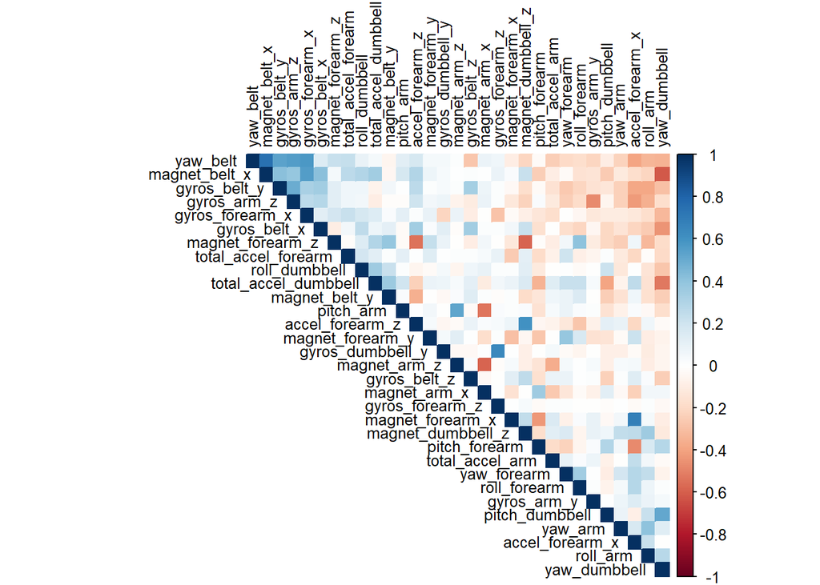

```r
cor_mat <- cor(final_training[,colnames(final_training)!= "classe"])
corrplot(cor_mat, order = "FPC", method = "color", type = "upper",
         tl.cex = 0.8, tl.col = rgb(0, 0, 0))
```

## Model training

In this assignment, we want to test three different classification type models:

- CART
- Random Forest
- eXtreme Gradient Boosting

### CART - Classification trees

We first train the model and visualize it with the *fancyRpartPlot()* function.

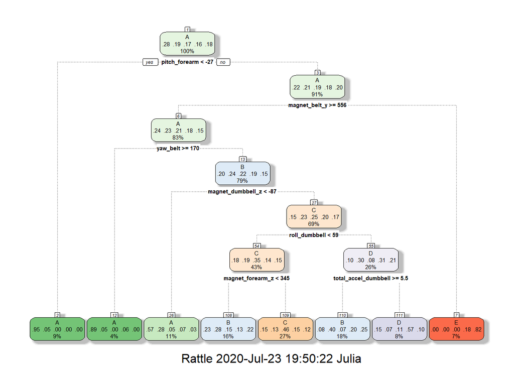

```r
set.seed(123)
ModFit1 <- train(classe~., method="rpart", data = final_training)
fancyRpartPlot(ModFit1$finalModel)
```

Predicting on the final_testing data set yields

```r
pred1 <- predict(ModFit1,newdata=final_testing)
cm1 <- confusionMatrix(pred1,as.factor(final_testing$classe))
cm1
```

```
## Confusion Matrix and Statistics
##
##           Reference
## Prediction   A   B   C   D   E
##          A 860 175  26  47  18
##          B 273 577 156 271 392
##          C 192 172 636 198 151
##          D  68  25  36 218  45
##          E   2   0   1  70 295
##
## Overall Statistics
##
##                Accuracy : 0.5273
##                  95% CI : (0.5132, 0.5414)
##     No Information Rate : 0.2845
##     P-Value [Acc > NIR] : < 2.2e-16
##
##                   Kappa : 0.4047
##
##  Mcnemar's Test P-Value : < 2.2e-16
##
## Statistics by Class:
##
##                      Class: A Class: B Class: C Class: D Class: E
## Sensitivity            0.6165   0.6080   0.7439  0.27114  0.32741
## Specificity            0.9242   0.7239   0.8239  0.95756  0.98176
## Pos Pred Value         0.7638   0.3457   0.4715  0.55612  0.80163
## Neg Pred Value         0.8584   0.8850   0.9384  0.87012  0.86640
## Prevalence             0.2845   0.1935   0.1743  0.16395  0.18373
## Detection Rate         0.1754   0.1177   0.1297  0.04445  0.06015
## Detection Prevalence   0.2296   0.3403   0.2751  0.07993  0.07504
## Balanced Accuracy      0.7703   0.6660   0.7839  0.61435  0.65459
```

The accuracy of the classification tree model is 52.73%, hence the out-of-sample-error is 47.27%.

### Random Forest

Next, we want build a random forest prediction model. Using cross validation in the *trainControl* function, we define the model as follows:

```r
set.seed(123)
train_control_rf <- trainControl(method="cv", number=3)
ModFit2 <- train(classe~., data =final_training, method = "rf", trControl = train_control_rf)
ModFit2$finalModel
```

```
##
## Call:
##  randomForest(x = x, y = y, mtry = param$mtry)
##                Type of random forest: classification
##                      Number of trees: 500
## No. of variables tried at each split: 2
##
##         OOB estimate of  error rate: 0.81%
## Confusion matrix:
##      A    B    C    D    E  class.error
## A 4181    4    0    0    0 0.0009557945
## B   12 2823   10    0    3 0.0087780899
## C    0   24 2533   10    0 0.0132450331
## D    0    0   44 2365    3 0.0194859038
## E    0    0    3    6 2697 0.0033259424
```

Let’s predict the new values with the random forest model:

```r
pred2 <- predict(ModFit2, newdata = final_testing)
cm2 <- confusionMatrix(pred2,as.factor(final_testing$classe))
cm2
```

```
## Confusion Matrix and Statistics
##
##           Reference
## Prediction    A    B    C    D    E
##          A 1395    3    0    0    0
##          B    0  943    8    0    0
##          C    0    3  845   15    1
##          D    0    0    2  789    2
##          E    0    0    0    0  898
##
## Overall Statistics
##
##                Accuracy : 0.9931
##                  95% CI : (0.9903, 0.9952)
##     No Information Rate : 0.2845
##     P-Value [Acc > NIR] : < 2.2e-16
##
##                   Kappa : 0.9912
##
##  Mcnemar's Test P-Value : NA
##
## Statistics by Class:
##
##                      Class: A Class: B Class: C Class: D Class: E
## Sensitivity            1.0000   0.9937   0.9883   0.9813   0.9967
## Specificity            0.9991   0.9980   0.9953   0.9990   1.0000
## Pos Pred Value         0.9979   0.9916   0.9780   0.9950   1.0000
## Neg Pred Value         1.0000   0.9985   0.9975   0.9964   0.9993
## Prevalence             0.2845   0.1935   0.1743   0.1639   0.1837
## Detection Rate         0.2845   0.1923   0.1723   0.1609   0.1831
## Detection Prevalence   0.2851   0.1939   0.1762   0.1617   0.1831
## Balanced Accuracy      0.9996   0.9958   0.9918   0.9902   0.9983
```

For random forest, we obtained a very high accuracy of 99.31%, resulting in an out-of-sample-error of only .69%

### Extreme Gradient Boosting

Finally, we want to evaluate an xgb model.

```r
set.seed(123)
train_control_xgb <- trainControl(method="cv", number=3)
ModFit3 <- train(classe~., data =final_training, method = "xgbTree", trControl = train_control_xgb)
ModFit3$finalModel
```

```
## ##### xgb.Booster
## raw: 483.3 Kb
## call:
##   xgboost::xgb.train(params = list(eta = param$eta, max_depth = param$max_depth,
##     gamma = param$gamma, colsample_bytree = param$colsample_bytree,
##     min_child_weight = param$min_child_weight, subsample = param$subsample),
##     data = x, nrounds = param$nrounds, num_class = length(lev),
##     objective = "multi:softprob")
## params (as set within xgb.train):
##   eta = "0.4", max_depth = "3", gamma = "0", colsample_bytree = "0.6", min_child_weight = "1", subsample = "0.5", num_class = "5", objective = "multi:softprob", validate_parameters = "TRUE"
## xgb.attributes:
##   niter
## callbacks:
##   cb.print.evaluation(period = print_every_n)
## # of features: 31
## niter: 150
## nfeatures : 31
## xNames : yaw_belt gyros_belt_x gyros_belt_y gyros_belt_z magnet_belt_x magnet_belt_y roll_arm pitch_arm yaw_arm total_accel_arm gyros_arm_y gyros_arm_z magnet_arm_x magnet_arm_z roll_dumbbell pitch_dumbbell yaw_dumbbell total_accel_dumbbell gyros_dumbbell_y magnet_dumbbell_z roll_forearm pitch_fo…
## problemType : Classification
## tuneValue :
##     nrounds max_depth eta gamma colsample_bytree min_child_weight subsample
## 93     150         3 0.4     0              0.6                1       0.5
## obsLevels : A B C D E
## param :
##  list()
```

Now, we validate the xgb model on the testing data partition to determine its accuracy.

```r
pred3 <- predict(ModFit3, newdata = final_testing)
cm3 <- confusionMatrix(pred3,as.factor(final_testing$classe))
cm3
```

```
## Confusion Matrix and Statistics
##
##           Reference
## Prediction    A    B    C    D    E
##          A 1395    3    0    0    0
##          B    0  936   13    0    0
##          C    0   10  835   16    2
##          D    0    0    7  787    1
##          E    0    0    0    1  898
##
## Overall Statistics
##
##                Accuracy : 0.9892
##                  95% CI : (0.9859, 0.9919)
##     No Information Rate : 0.2845
##     P-Value [Acc > NIR] : < 2.2e-16
##
##                   Kappa : 0.9863
##
##  Mcnemar's Test P-Value : NA
##
## Statistics by Class:
##
##                      Class: A Class: B Class: C Class: D Class: E
## Sensitivity            1.0000   0.9863   0.9766   0.9789   0.9967
## Specificity            0.9991   0.9967   0.9931   0.9980   0.9998
## Pos Pred Value         0.9979   0.9863   0.9676   0.9899   0.9989
## Neg Pred Value         1.0000   0.9967   0.9951   0.9959   0.9993
## Prevalence             0.2845   0.1935   0.1743   0.1639   0.1837
## Detection Rate         0.2845   0.1909   0.1703   0.1605   0.1831
## Detection Prevalence   0.2851   0.1935   0.1760   0.1621   0.1833
## Balanced Accuracy      0.9996   0.9915   0.9848   0.9885   0.9982
```

## Test Cases - Course Project Prediction Quiz

Based on the accuracy value, we choose the random forest model to predict the 20 different test cases. The output will also be used for the quiz.

```r
final_results <- predict(ModFit2, newdata = test)
final_results
```

```
##  [1] B A B A A E D B A A B C B A E E A B B B
## Levels: A B C D E
```